# Math 300 NTI Lesson 24

Understanding Confidence Intervals

Professor Bradley Warner

July, 2022

## Objectives

1. Explain how to construct a confidence interval using both the percentile method and the standard error method including assumptions.
2. Explain how changing the confidence level impacts the width of a confidence interval.

## Reading

[Chapter 8.3](https://moderndive.com/8-confidence-intervals.html#ci-build-up)

## Lesson

*Remember that you will be running this more like a lab than a lecture. You want them using `R` and answering questions. Have them open the notes rmd and work through it together.*

Work through the learning checks LC 8.3 - LC 8.4.

- All confidence intervals have the same interpretation. It is the construction that may differ. INSTRUCTORS NOTE: the text defers discussion on confidence interval interpretation to section 8.5. Feel free to discuss interpretation now if it comes up. Most importantly, emphasize that the interval DOES NOT tell us that there’s a 95% probability that $\mu$ falls in this range.
- The reason we use an interval is because a point estimate has variation. Once we know the sampling distribution, we can construct an interval. Using the bootstrap gives us an estimate of the sampling distribution of the point estimate.
- We are going to do a look ahead and use `R` to construct the percentile method confidence interval.
- The percentile method is easier to understand but tends to be biased. There are many methods to adjust for this but for the purpose of this course both methods are acceptable.

### Libraries

```r
library(tidyverse)
library(moderndive)
```

### Review

As a review, let’s construct the bootstrap distribution of the sample mean for our pennies data. This requires use to use our skills on wrangling data frames.

```r
head(pennies_sample)
```

```
## # A tibble: 6 x 2
##      ID  year
##   <int> <dbl>
## 1     1  2002
## 2     2  1986
## 3     3  2017
## 4     4  1988
## 5     5  2008
## 6     6  1983
```

```r
set.seed(52249)
bootstrap_dist<-pennies_sample %>%
  rep_sample_n(size = 50, replace = TRUE, reps = 1000) %>%
  group_by(replicate) %>%
  summarize(ave=mean(year))
```

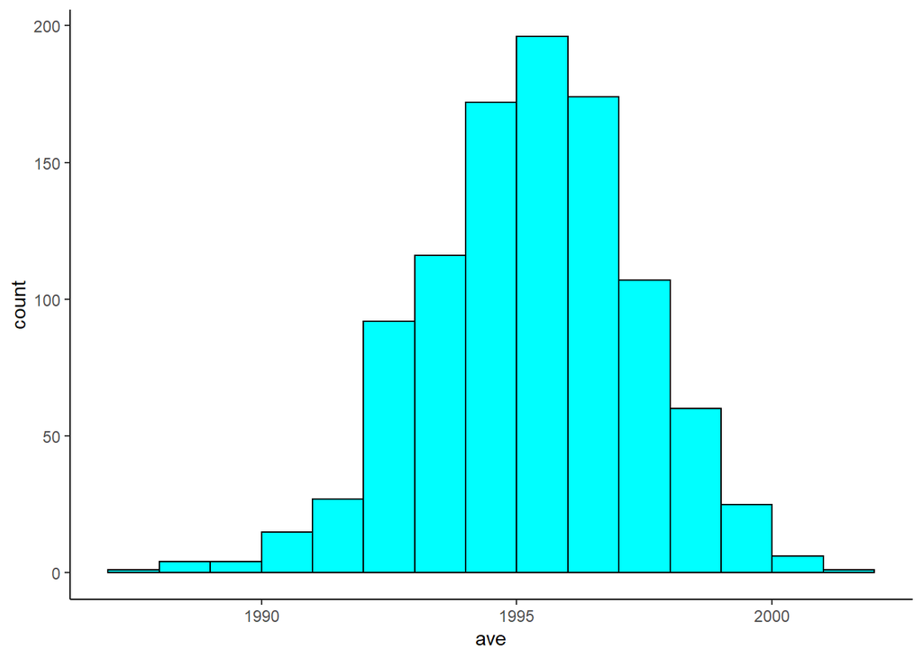

```r
bootstrap_dist %>%
  ggplot(aes(x=ave)) +
  geom_histogram(binwidth = 1, color = "black", boundary = 1990, fill = "cyan") +
  theme_classic()
```

#### Confidence Interval, Percentile Method

```r
bootstrap_dist %>%
  summarize(center=mean(ave),
            lower=quantile(ave,probs=0.025),
            upper=quantile(ave,probs=.975))
```

```
## # A tibble: 1 x 3
##   center lower upper
##    <dbl> <dbl> <dbl>
## 1  1995. 1991. 1999.
```

This distribution seems to be roughly symmetric.

#### Confidence Interval, standard error method

```r
bootstrap_dist %>%
  summarize(center=mean(ave),
            lower=center-sd(ave)*qnorm(.975),
            upper=center+sd(ave)*qnorm(.975))
```

```
## # A tibble: 1 x 3
##   center lower upper
##    <dbl> <dbl> <dbl>
## 1  1995. 1991. 1999.
```

### LC 8.3 (Objective 1)

**(LC8.3)** What condition about the bootstrap distribution must be met for us to be able to construct confidence intervals using the standard error method?

**Solution**:

We can only use the standard error rule when the bootstrap distribution is roughly normally distributed.

### LC 8.4 (Objective 2)

**(LC8.4)** Say we wanted to construct a 68% confidence interval instead of a 95% confidence interval for $\mu$. Describe what changes are needed to make this happen. Hint: we suggest you look at Appendix A.2 on the normal distribution.

**Solution**:

Thus, using our 68% rule of thumb about normal distributions from Appendix A.2, we can use the following formula to determine the lower and upper endpoints of a 68% confidence interval for $\mu$:

$$\overline{x} \pm 1 \cdot SE =
(\overline{x} - 1 \cdot SE, \overline{x} + 1 \cdot SE)$$

Or using `R`

```r
qnorm(.68+.32/2)
```

```
## [1] 0.9944579
```

This is where the 1 came from.

## Documenting software

- File creation date: 2022-07-06
- R version 4.1.3 (2022-03-10)
- `tidyverse` package version: 1.3.1
- `moderndive` package version: 0.5.4